# STAT5040: Fourier Analysis of Time Series Ch8

Fall 2020

## The Spectrum

## Introduction

- We focus on the mathematical aspect in previous chapters, e.g.,
  - fitting sinusoids of known/unknown frequency, and
  - the fast Fourier transform (FFT) algorithms.
- We now discuss the statistical aspect with some real data sets.
  - How to do spectral analysis of time series?
  - How to deal with some practical issues such as change in scale?
  - How to interpret the results from spectral analysis?
- The data is available [here](https://www4.stat.ncsu.edu/~bloomfld/FATS/).
  - The link is not up-to-date in the book.
- My code is available here.
  - Modern libraries like xts are used.

## Periodogram Analysis

## Definitions recall

- Discrete Fourier transform (Section 5.1): \[ d(f_j) = \frac{1}{n} \sum_{t=0}^{n-1} x_t \exp(-2 \pi i f_j t), \quad j=0,1,\ldots,n-1. \]
  - Equivalent to fitting sinusoids (Section 4.1)
- Periodogram (Section 6.1): \[ I(f) = n|d(f)|^2. \]
  - An estimate of the spectrum/spectral density

## Problem: change in scale

- No sinusoids can match oscillations that grow in amplitude
  - Possible cause: inflation?

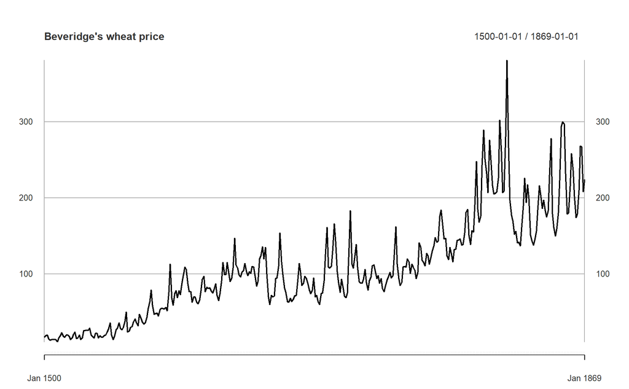

## Beveridge: “index of fluctuation”

- Each value is divided by the average of 31 centered adjacent values
  - Idea: smoothing

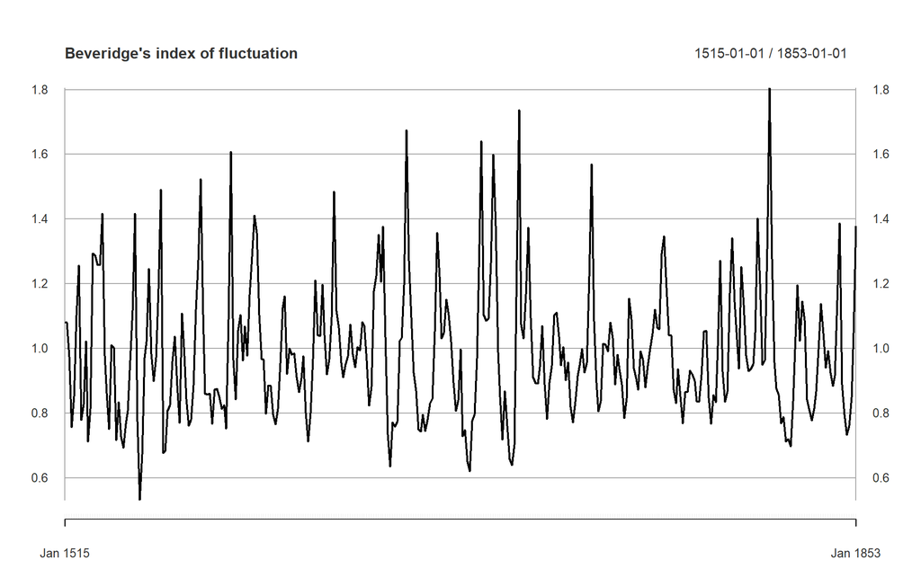

## Motivation: unobserved components model

- Proposed by Harvey (1989)
- Bloomfield only considered the trend \(T_t\) and irregular component \(I_t\)
  - Multiplicative model: \(x_t = T_t I_t\)
  - Additive model: \(x_t = T_t +I_t\)
- Interpretation for wheat price
  - \(T_t\): driven by long-run economic forces such as inflation
  - \(I_t\): caused by short-run effects such as changes in supply from year to year
  - \(T_t\) is an unwanted complication in the analysis and approximated by 31-year moving average
  - \(I_t\) is then estimated by the index of fluctuation
  - Closely related to filtering in Section 7.2

## Problem: spurious periodicities

- Beveridge (1921) gave periodogram ordinates based on index of fluctuation
  - It solved the change in scale problem in analyzing periodicity
  - However, Slutsky pointed out that operations involving linear filtering might lead to spurious periodicities in 1927
  - Intuitively, this means that transformation may distort the original periodicity
    - I try to replicate his estimates but it seems that additional cleanings are necessary (p.139)
    - As the original paper is not found online, I choose to discuss the idea only
- Under multiplicative model, we can correct for the transfer function to mitigate spurious periodicities
  - As also shown by Granger and Hughes (1971)
  - For index of fluctuation, the transfer function is \(D_{31}(f)\), a Dirichlet kernel (Section 2.2)
  - After correction, the peak changes as compared with Beveridge (1921)

## (Part of) Beveridge’s periodogram

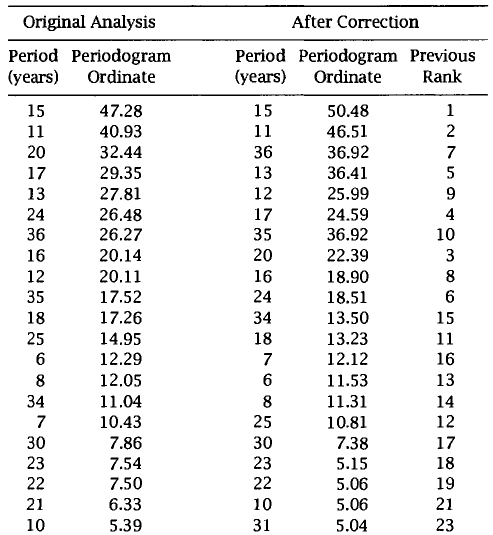

## Logarithmic transformation

- Alternatively, we can do logarithmic transformation under multiplicative model \[ \ln x_t = \ln T_t +\ln I_t \]
- Interpretation
  - \(\ln T_t\): the typical value of \(x_t\) in the neighborhood of \(t\)
  - \(I_t\): a dimensionless quantity close to 1 so that \(\ln I_t\) fluctuates around 0
- Vs index of fluctuation
  - Nonsinusoidal behavior of a series introduce structure into its Fourier transform
  - However, they are not revealed by the periodogram (Section 6.5)
  - Logarithms can reduce this behavior such as spikiness of the peaks
    - Reasonable as we are interested in \(I_t\) but not the extreme behaviors

## Logarithmic transformation

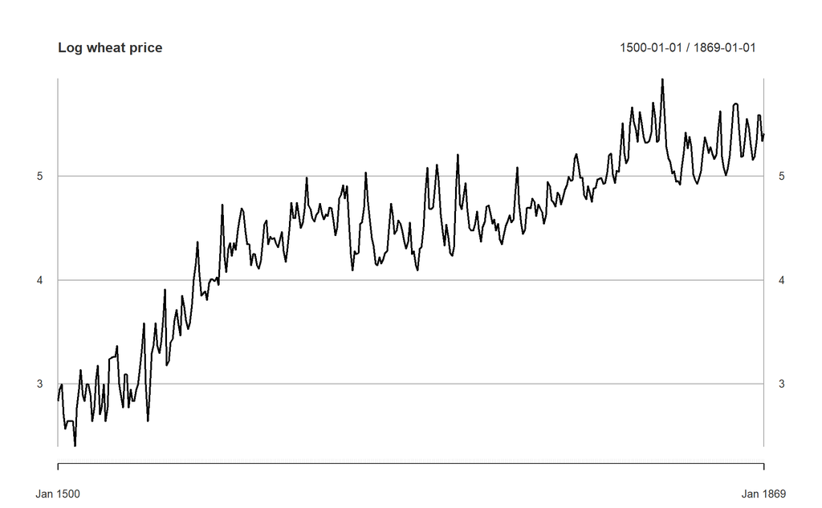

## Data cleaning

- Beveridge (1921) argued that the early part of the series was unreliable due to fewer sources
- The later part was of a different nature due to economic changes in the 19th century
  - I have not looked into wheat market history but it sounds reasonable
  - We should also be aware of the underlying structure/data quality when we perform statistical analysis
- After clearning, the periodogram of logarithms and index of fluctuation are similar

## Data cleaning

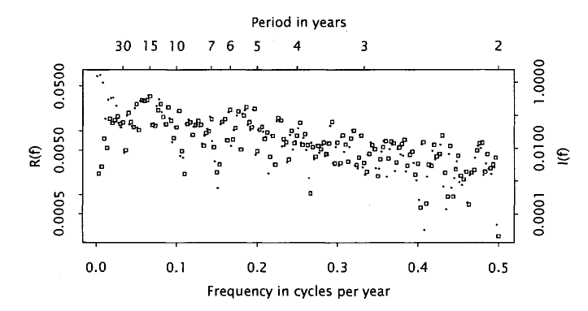

Periodogram of logarithms (dots) and index of fluctuation (squares)

## Analysis of segments: idea

- Idea: if there is periodicity in a series, it should hold for segments of the same series
- Beveridge (1921) also gave some terms from the periodogram of two halves of the series

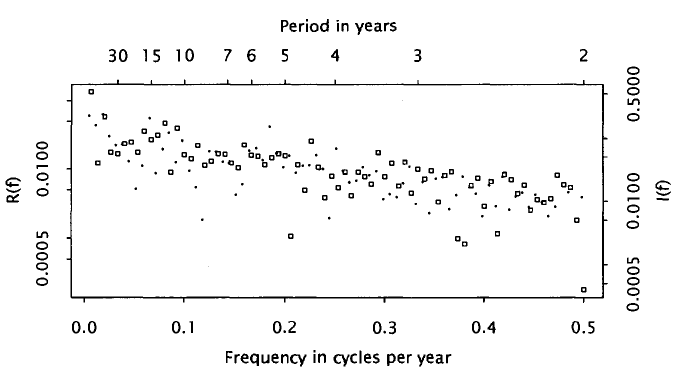

Periodogram of logarithms of two halves (1545-1694=squares, 1695-1844=dots)

## Analysis of segments: wheat price

- The two periodograms have the same general shape
  - Large at lowest frequencies and show a broad peak between 0.06 and 0.10 cycles per year
  - Then show a gentle decline over the rest of the periodogram with small fluctuations
- However, the fine structures are quite unrelated
  - A local peak in one is just as likely to be matched by a local trough as a local peak in the other
- These shows that the fine strucuture is not repeated from one segment to the next
  - But the broad features show a statistical regularity or consistency across segments
    - I think these terms can be confusing in the literature
- Thus the fine structure of these two periodograms is not characteristic of the series as a whole
  - Broad features do not appear to vary in this way and may be characteristic of the whole series
  - In contrast, the periodograms of the variable star data have similar fine structures

## Analysis of segments: variable stars

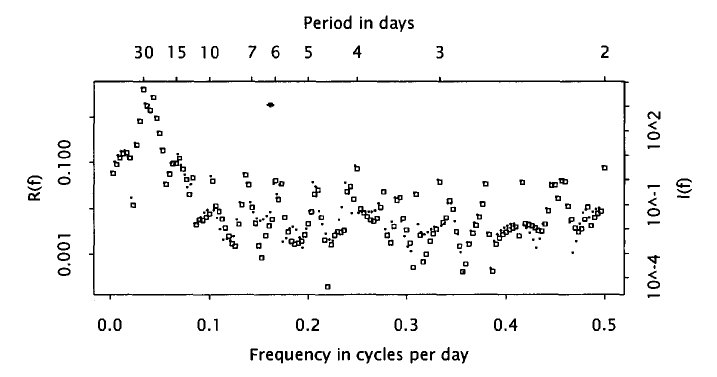

Periodogram of two halves of the variable star series

## Analysis of segments: conclusion

- Bloomfield is trying to motivate the concept of spectrum here
  - A raw periodogram may not be useful
    - For variable star, it is directly useful
    - For wheat price, the fine structure should be suppressed to focus on the broad behavior
  - This suggests a smoothed periodogram
    - So that periodograms of segments may be regarded as the same underlying smooth curve
    - Such smooth curve is called the spectrum or spectral density of the series
    - Spectrum exists for many time series models (Chapter 9)

## Spectrum Estimation

## Bartlett’s method

- Suggested by Bartlett (1948)
1. Split the series into \(k\) non-overlapping segments of similar length
2. For each segment, compute its periodogram
3. Average the result of the periodograms above for the \(k\) segments
- Welch’s method: allow overlapping
  - It can reduce noise in exchange for reducing the frequency resolution
  - Often desirable in finite sample
- Average of logarithms or logarithms of averages can both be used
  - The latter is preferred since it puts more weight on larger values
  - Small values are the most susceptible to perturbations such as leakage from other frequencies

## Bartlett’s method

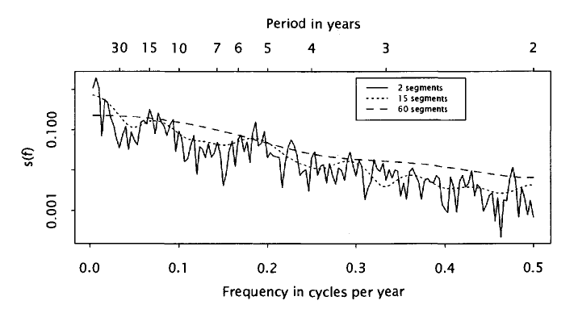

Average segment periodograms for the logarithms of the wheat prices, 1545-1844

## Bartlett spectrum estimate

- To understand the effect of Bartlett’s method, we try to find the “periodogram” that it is producing
- For simplicity, Bloomfield assumed \(x_t\) are deviations around 0
  - If they are not, we can do demean and arrive at a similar result
- Now note that \[ \begin{aligned} I(f) &= n |d(f)|^2 = n \cdot d(f) \cdot \overline{d(f)} \\ &= \frac{1}{n} \sum_t \sum_{t'} x_t x_{t'} \exp\big\{ -2\pi i f(t-t') \big\}. \end{aligned} \]
- As \(t-t' \in [-n+1, n-1] \cap \mathbb{Z}\), we can rewrite the above as \[ \begin{aligned} I(f) &= \frac{1}{n} \sum_{r=-n+1}^{n-1} \sum_{t-t'=r} x_t x_{t'} \exp(-2\pi i f r) \\ &= \frac{1}{n} \sum_{r=-n+1}^{n-1} \exp(-2\pi i f r) \sum_{t-t'=r} x_t x_{t'}. \end{aligned} \]

## Bartlett spectrum estimate

- Suppose the data are divided into \(k\) non-overlapping segments of length \(m = n/k\)
  - \(I_j(f)\): the periodogram of the \(j\)-th segment
  - \(c_{j,r}\): the autocovariance of the \(j\)-th segment at lag \(r\)
- The average of these periodogram is \[ \begin{aligned} \hat{s}(f) &= \frac{1}{k} \sum_{j=1}^k I_j(f) = \sum_{|r|<m} \left( \frac{1}{k} \sum_{j=1}^k c_{j,r} \right) \exp(-2\pi i f r) \\ &= \sum_{|r|<m} \left( 1 -\frac{|r|}{m} \right) \frac{1}{k(m-|r|)} \sum_{j=1}^k m c_{j,r} \exp(-2\pi i f r). \end{aligned} \]
- Now \(\sum_{j=1}^k m c_{j,r}\) is like \(nc_r\), a sum of products of the form \(x_t x_{t+r}\)
  - Except that the term is included only if \(x_t\) and \(x_{t+r}\) fall into the same segment
  - So \(\{k(m-|r|)\}^{-1} \sum_{j=1}^k m c_{j,r}\) is the average of these products
  - It makes sense to replace with \(nc_r/(n-|r|)\) (whole series version)

## Bartlett spectrum estimate

- Replacing \(\{k(m-|r|)\}^{-1} \sum_{j=1}^k m c_{j,r}\) with \(nc_r/(n-|r|)\), the modified version is \[ \hat{s}_{B}(f) = \sum_{|r|<m} \frac{1-|r|/m}{1-|r|/n} c_r \exp(-2\pi i f r) = \sum_{|r|<m} w_r c_r \exp(-2\pi i f r), \]
  - where \(w_r = (1-|r|/m)/(1-|r|/n)\).
  - \(\hat{s}_{B}(f)\) is known as the Bartlett spectrum estimate
  - \(w_r\) is the weight at lag \(r\)
- Vs periodogram
  - All terms with \(|r| \ge m\) will be omitted
  - The remaining terms are progressively reduced in magnitude by the weight \(w_r\)
  - Both effects make \(\hat{s}_{B}(f)\) smoother than the periodogram
  - Varying the truncation point \(m\) provides control over the degree of smoothness
    - \(m\) is also called the bandwidth
  - However, \(\hat{s}_{B}(f)\) is not guaranteed to be positive unlike \(I(f)\)

## Bartlett spectrum estimate

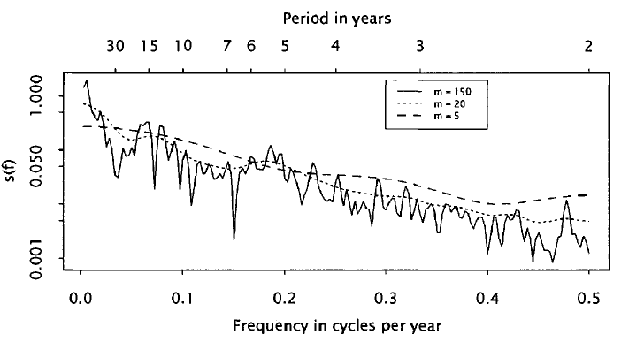

Bartlett spectrum estimates for the logarithms of the wheat prices, 1545-1844

## Smoothing the periodogram

- The Bartlett spectrum estimate motivates smoothing the periodogram with other data windows \(w_r\)
  - A significant property is that \(w_r\) decays from 1 when \(r=0\) to 0 when \(r=\pm m\)
    - This is common but not necessary, at least for long run variance estimation
    - See, e.g., Andrews (1991)
  - Anderson (1994) lists the most commonly used windows and their properties
  - Bartlett window is the only window that decays linearly and rarely used in practice
    - I think Bartlett window is quite popular, at least for long run variance estimation as well
    - It is also computationally efficient for spectrum estimation. See Xiao and Wu (2011)
- The smoothing strategy is attractive when the truncation point \(m\) is small
  - Only \(m\) autocovariances need to be computed
  - If \(m\) is large, the autocovariances can be computed efficiently using FFT and its inverse

## Computing the autocovariances

- From previous derivation (p.144), we know that the periodogram is itself a Fourier series
- This raises the possibility of using FFT to obtain autocovariance estimates
- When the periodogram is evaluated at a Fourier frequency \(f_j = j/n\), \[ I(f_j) = \sum_{r=0}^{n-1} (c_r +c_{n-r}) \exp(-2\pi i f_j r), \]
  - provided that \(c_r\) is defined to be 0 for \(|r| \ge n\).
- Therefore, we have \[ c_r +c_{n-r} = \frac{1}{n} \sum_{j=0}^{n-1} I(f_j) \exp(2\pi i f_j r), \]
  - which may be computed using inverse FFT.
  - However, \(c_{r}\) is not symmetric with \(c_{n-r}\)
  - This computation is only fine for small \(r\) as giving approximations of \(c_r\)

## Computing the autocovariances

- The problem of \(c_r +c_{n-r}\) can be solved by using a finer grid \(f'_j=j/n'\) for some \(n' > n\)
- We can pad the data with a block of \(n'-n\) zeros. Then \[ I(f'_j) = \sum_{r=0}^{n-1} (c_r +c_{n'-r}) \exp(-2\pi i f'_j r). \]
- Inversion now gives \[ c_r +c_{n'-r} = \frac{1}{n'} \sum_{j=0}^{n'-1} I(f'_j) \exp(2\pi i f'_j r), \]
  - which yields \(c_0, c_1, \ldots, c_{n'-n}\) exactly.
  - If \(n'=2n-1\), all autocovariance estimates are obtained.
    - Note that \(I(f'_j)\) only sum to \(n-1\)
    - Probably why the zeros may not contaminate the estimates
  - FFT costs \(O(n \log n)\) times, which is faster than brute force \(O(n^2)\)

## Representation of a spectrum estiamte

- Suppose a spectrum estimate is given by \(\hat{s}(f) = \sum_{|r|<n} w_r c_r \exp(-2\pi i f r)\),
  - where a truncation point \(m\) is no longer assumed.
- By the integral inversion formula (p.40), we have \(c_r = \int_0^1 I(f) \exp(2\pi i f r) df\).
  - Then \(\hat{s}(f) = \int_0^1 W_n(f-f') I(f') df'\),
  - where \(W_n(f) = \sum_{|r| < n} w_r \exp(-2 \pi i f r)\).
- Therefore, any \(\hat{s}(f)\) of the above form may be written as an integral average of \(I(f)\)
  - The \(W_n(f)\) is called the spectral window associated with the spectral estimate
    - There is one-to-one relationship between \(W_n(f)\) and \(w_r\)

## Spectral window

- The spectral window of the Bartlett estimate has no closed form
  - The window is \(w_r = (1-|r|/m)/(1-|r|/n)\)
- Modified Bartlett estimate
  - The window is \(w_r = (1-|r|/m)\mathbb{I}_{|r|<m}\)
  - The corresponding spectral window is \[ W_n(f) = \sum_{|r|<m} \left( 1 -\frac{|r|}{m} \right) \exp(-2\pi i f r) = m D_m(f)^2, \]
  - where \(D_m(f)\) is the Dirichlet kernel (Section 2.2).
- If the spectral window and periodogram are both nonnegative,
  - then the spectrum estimate is guaranteed to be nonnegative.
    - Important in long run variance estimation

## Spectral window

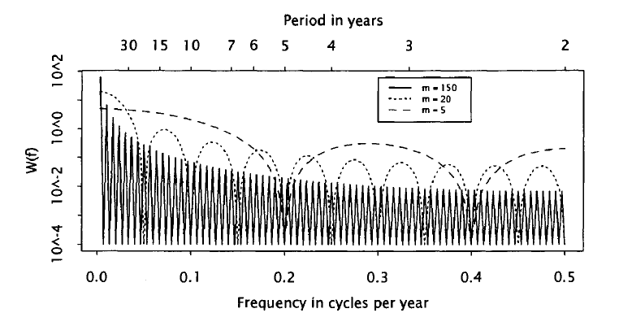

Spectral windows for the modified Bartlett spectrum estimates

## Modified Bartlett spectrum estimate

- The central peak in the spectral window of the modified Bartlett estimate is of height \(m\)
- The first zeros on either side are at \(f=\pm 1/m\) cycles per unit time
- However, a sizable proportion of the mass is contained in the sidelobes which decay slowly
- The periodogram values at some distance from \(f\) may also contribute substantially to the integral
- The estimated spectrum in one frequency may be swamped by leakage from another with high power
  - Even when these bands are not adjacent
  - Such leakage is different than the leakage in the periodogram itself
  - The major source is the sidelobes in the smoothing spectral window
- The sidelobes of the modified Bartlett window are larger and decay more slowly
  - As compared with Anderson (1994)
  - Thus it is rarely used
- Note that sidelobes are bound to exist for any spectrum estimates with truncation point \(m\)

## Another representation of a spectrum estiamte

- From the representation \(\hat{s}(f) = \int_0^1 W_n(f-f') I(f') df'\), we have \[ \hat{s}(f) = \int_0^1 W(f') I(f-f') df', \]
  - for suitable function \(W(f)\).
- Furthermore, we can write \(w_r = \int_0^1 W(f) \exp(2\pi i f r) df\).
  - Mathematically, \(w_r\) are the Fourier coefficients of \(W(f)\)
  - \(W_n(f)\) is a partial sum of the Fourier series for \(W(f)\)
    - Recall \(W_n(f)\) is the spectral window
    - I understand this as constructing \(w_r\) reversely from the spectral window
- Daniell (1946) suggested \(W(f) = (2\delta)^{-1} \mathbb{I}_{|f| < \delta}\).
  - The resulting estimate is the integral analog of simple moving average filer (Section 7.2)
  - It may be applied successively to build up more complex filter (p.157)
- I will skip the remaining of Section 8.5 which discuss the computation of discrete \(\hat{s}(f)\)

## Choice of a spectral window

- Four factors need to be considered when choosing a spectral window:
  - Resolution or bandwidth
  - Stability
  - Leakage
  - Smoothness
- Resolution: the ability of a spectrum estimate to represent fine structure in the frequency
  - Such as narrow peaks in the spectrum
  - A narrow peak in the periodogram is usually spread out into a broader peak in the spectrum
  - This peak is roughly an image of the spectral window and its width is the bandwidth
  - If the spectrum contains two close narrow peaks, they may overlap and form a single peak
  - In this case, the estimate has failed to resolve the peaks
- Stability: the extent to which estimates from different segments agree
  - In other words, it is the ability to remove irrelevant fine structure
  - Resolution and stability are conflicting requirements
    - Easy to see by definition
  - Section 9.5 gives a statistical treatment of the stability of spectrum estimates

## Example: wheat price

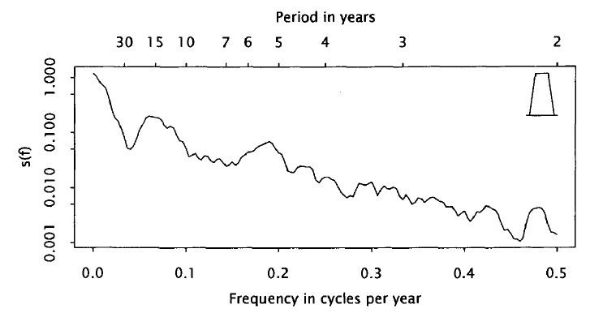

Smoothed periodogram of logarithms of wheat price index, with spectral window inset (Modified Daniell filer, m=6.)

## Example: wheat price

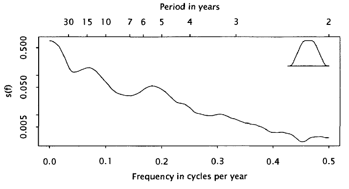

Smoothed periodogram of logarithms of wheat price index, with spectral window inset (Modified Daniell filer, m=6,12.)

## Example: sunspot

- For sunspot data, the spectral weights have the same span as the wheat price
  - Which means they cover the same number of periodogram ordinates
  - However, they are smoother and have a narrower peak
  - The spectral estimates correspondingly show more rounded but slightly larger fluctuations
  - This argument is made more precise in Chapter 9
- For the square root transformation, refer to Section 6.7 for the idea
- Further discussion of the choice of a spectral window available in Jenkins (1961) and Parzen (1961)
  - I try to find a more recent survey but have not yet found one

## Example: sunspot

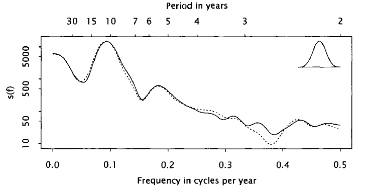

Smoothed periodogram of yearly sunspot numbers (solid line) and their square roots (broken line), with spectral window inset (Modified Daniell filer, m=6,6,6.)

## Reroughing the spectrum

- If \(\hat{s}(f)\) suffers from oversmoothing,
  - there are narrow-band features in the periodogram that were not fully transferred to \(\hat{s}(f)\).
  - They will appear partially in \(r(f)\), which can be extracted with another round of smoothing:

## Example: wheat price

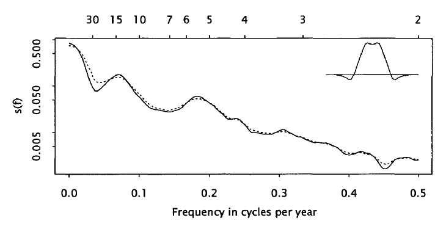

Twiced spectrum estiamte of wheat price index (solid line) and original esimtae (broken line) (Modified Daniell filer, m=6,12.)

## Example: sunspot

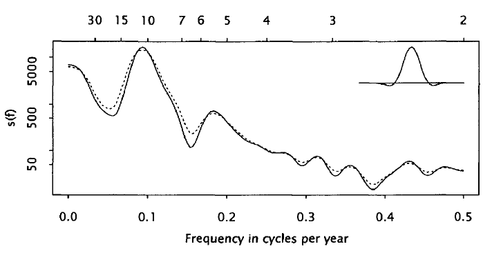

Twiced spectrum estiamte of yearly sunspot numbers (solid line) and original esimtae (broken line) (Modified Daniell filer, m=6,6,6.)

## Prewhitening

- Reroughing is closely related to prewhitening (Blackman and Tukey, 1959)
- Oversmoothing leads to leakage from frequency bands with high power to adjacent bands
  - From this perspective, oversmoothing is caused by a large dynamic range in the spectrum
- Prewhitening is a technique for reducing dynamic range prior to forming the periodogram
  - It reduces the leakage and allows the use of a more stable estimate with lower resolution
  - The simplest form of prewhitening is replacing the data by their first differences
    - I think differencing is also used as stationary transformation in practice
- Vs reroughing
  - Reroughing is an enhancement to spectrum estimation
  - Prewhitening is a form of preprocessing

## Concluding Remarks

## Comments

- Periodogram analysis
  - Some practical problems and their solutions are covered
  - The statistical regularity over different segments remains a concern
- Spectrum estimation
  - Smoothing the periodogram to focus on the broad behavior
  - From Fourier transform form to autocovariance form
  - Data windows and their corresponding spectral window
  - Choice of spectral window
  - Reroughing and prewhitening